# Classification and Regression Trees

GWU Intro to Data Science DATS 6101

2022-12-14

# 1 Source of the Data

```r
str(stroke_df)
```

```
## 'data.frame':    5110 obs. of  12 variables:
##  $ id               : int  9046 51676 31112 60182 1665 56669 53882 10434 27419 60491 ...
##  $ gender           : chr  "Male" "Female" "Male" "Female" ...
##  $ age              : num  67 61 80 49 79 81 74 69 59 78 ...
##  $ hypertension     : int  0 0 0 0 1 0 1 0 0 0 ...
##  $ heart_disease    : int  1 0 1 0 0 0 1 0 0 0 ...
##  $ ever_married     : chr  "Yes" "Yes" "Yes" "Yes" ...
##  $ work_type        : chr  "Private" "Self-employed" "Private" "Private" ...
##  $ Residence_type   : chr  "Urban" "Rural" "Rural" "Urban" ...
##  $ avg_glucose_level: num  229 202 106 171 174 ...
##  $ bmi              : chr  "36.6" "N/A" "32.5" "34.4" ...
##  $ smoking_status   : chr  "formerly smoked" "never smoked" "never smoked" "smokes" ...
##  $ stroke           : int  1 1 1 1 1 1 1 1 1 1 ...
```

- id (a unique identification number for each observation)
- gender (3 categories “Male”, “Female”, or “Other”)
- age (age of the individual)
- hypertension (blood pressure of an individual)
- heart_disease (history of any heart disease previously noted)
- ever_married (2 categories “No” or “Yes”)
- work_type (5 categories “children”, “govt_job”, “never_worked”, “private”, “self-employed”)
- residence_type (where does the individual reside “rural” or “urban”)
- avg_glucose_level (Average Blood Sugar level of an individual)
- bmi (Body Mass Index of the individual)
- smoking_status (smoking status of an individual)
- stroke (Target variable “1” or “0”)

# 2 Data Manipulation and Cleaning

- Converting the character value columns to categorical values and numerical values based on the type of the column.
- Checking for Null values in the dataset
- Null value imputation with mean
- subsetting the data into people who got stroke and the ones that didnt
- subsetting the data into male and females who got stroke
- created a separate categorical column for bmi using the bucketing system given in [Wikipedia](https://en.wikipedia.org/wiki/Body_mass_index)
- created a separate categorical column for average glucose level and age

```r
# since we had only 1 data point in others category for gender we are removing it
stroke_df = subset(stroke_df,gender!="Other")
summary(stroke_df)
```

```
##     gender          age        hypertension heart_disease ever_married
##  Female:2994   Min.   : 0.08   0:4611       0:4833        No :1756
##  Male  :2115   1st Qu.:25.00   1: 498       1: 276        Yes:3353
##  Other :   0   Median :45.00
##                Mean   :43.23
##                3rd Qu.:61.00
##                Max.   :82.00
##          work_type    Residence_type avg_glucose_level      bmi
##  children     : 687   Rural:2513     Min.   : 55.12    Min.   :10.30
##  Govt_job     : 657   Urban:2596     1st Qu.: 77.24    1st Qu.:23.80
##  Never_worked :  22                  Median : 91.88    Median :28.40
##  Private      :2924                  Mean   :106.14    Mean   :28.89
##  Self-employed: 819                  3rd Qu.:114.09    3rd Qu.:32.80
##                                      Max.   :271.74    Max.   :97.60
##          smoking_status stroke
##  formerly smoked: 884   0:4860
##  never smoked   :1892   1: 249
##  smokes         : 789
##  Unknown        :1544
##
##
```

# 3 Exploratory Data Analysis

## 3.1 Distribution of the numerical variables

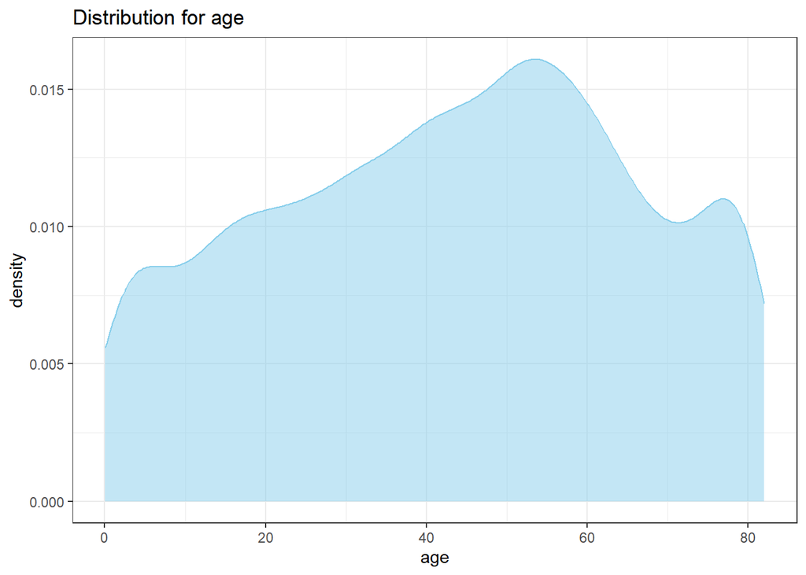

```r
ggplot(stroke_df, aes(x=age)) +  geom_density(fill="skyblue", color="skyblue", alpha=0.5)+ theme_bw() + theme()+ ggtitle("Distribution for age")
```

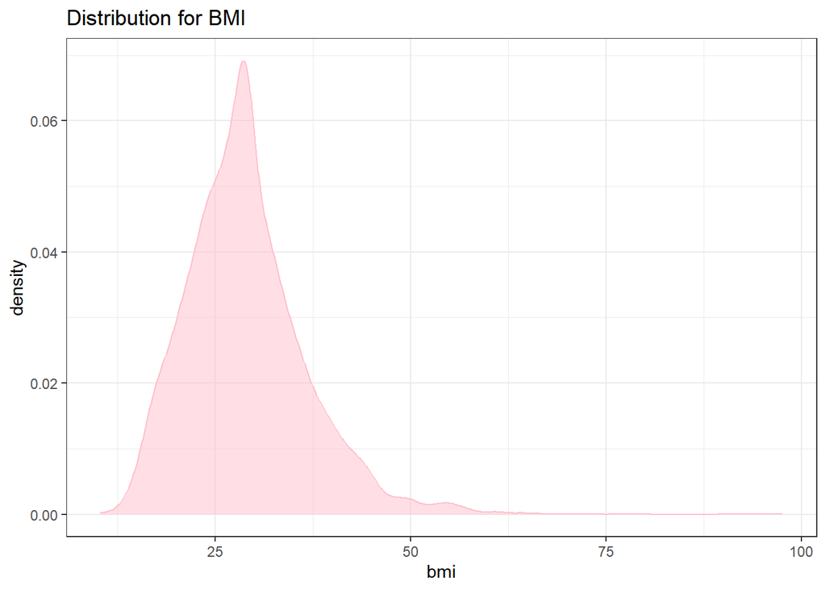

```r
ggplot(stroke_df, aes(x=bmi)) +  geom_density(fill="pink", color="pink", alpha=0.5)+ theme_bw() + theme()+ ggtitle("Distribution for BMI")
```

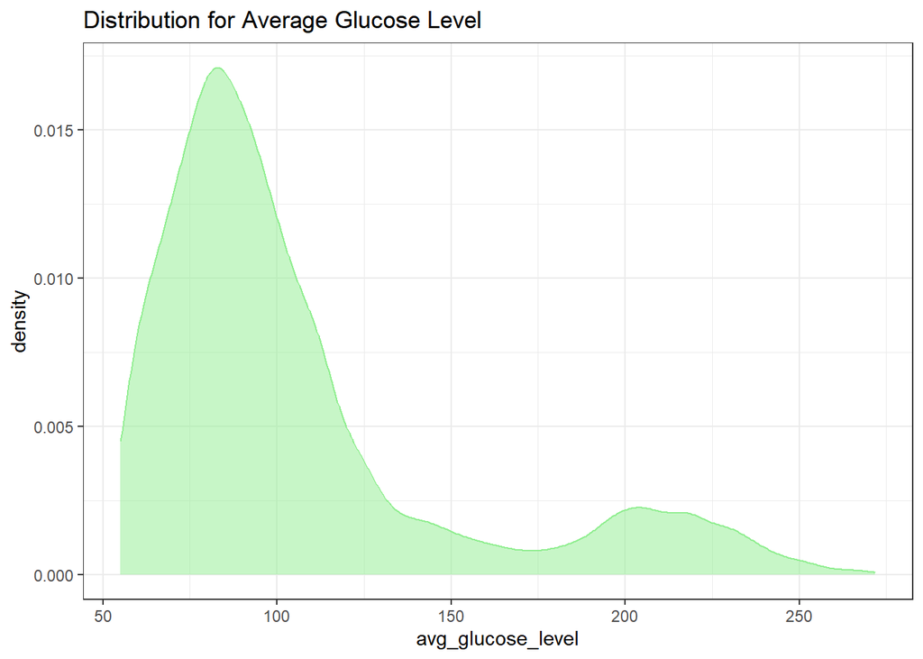

```r
ggplot(stroke_df, aes(x=avg_glucose_level)) +  geom_density(fill="lightgreen", color="lightgreen", alpha=0.5)+ theme_bw() + theme()+ ggtitle("Distribution for Average Glucose Level")
```

## 3.2 Distribution of Stroke (Target variable)

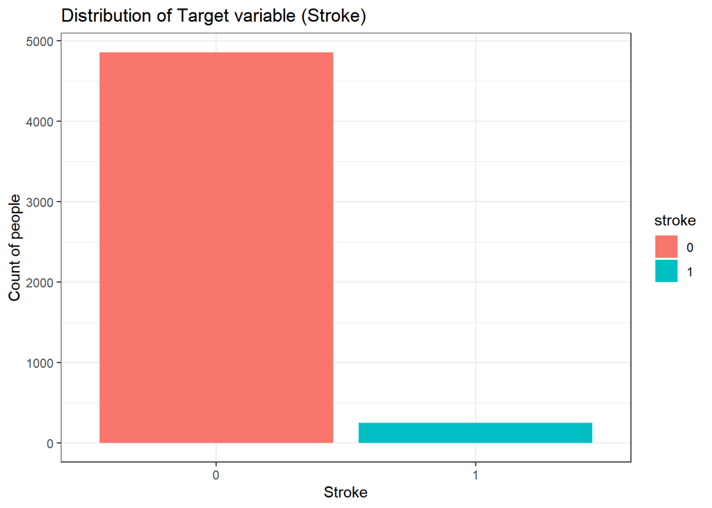

```r
ggplot(stroke_df, aes(x=stroke,fill=stroke))+geom_bar()+ggtitle("Distribution of Target variable (Stroke)")+ theme_bw() + theme()+ xlab("Stroke") + ylab("Count of people")
```

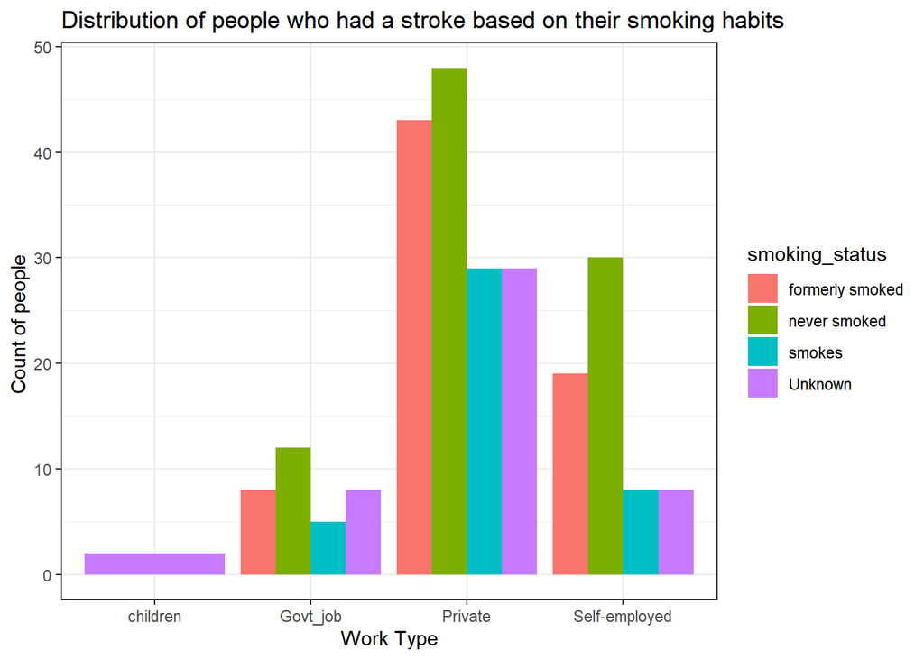

```r
ggplot(stroke_1,aes(x=work_type, fill= smoking_status))+geom_bar(position = "dodge")+ggtitle("Distribution of people who had a stroke based on their smoking habits")+ theme_bw() + theme()+ xlab("Work Type") + ylab("Count of people ")
```

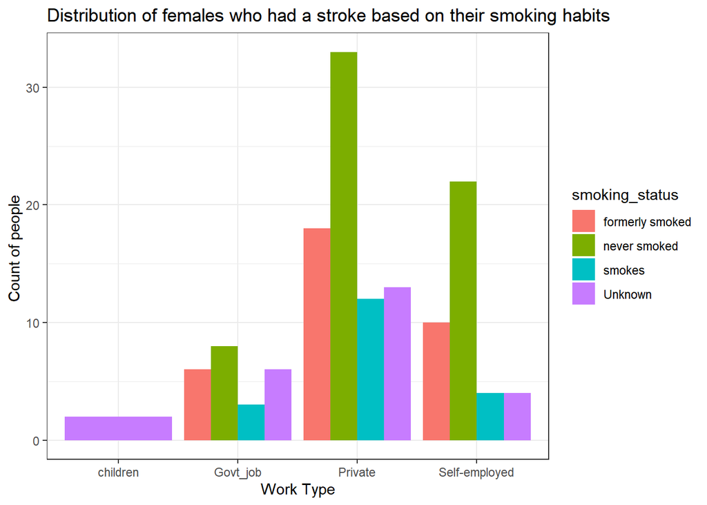

```r
ggplot(stroke_1_female,aes(x=work_type, fill= smoking_status))+geom_bar(position = "dodge")+ggtitle("Distribution of females who had a stroke based on their smoking habits")+ theme_bw() + theme()+ xlab("Work Type") + ylab("Count of people ")
```

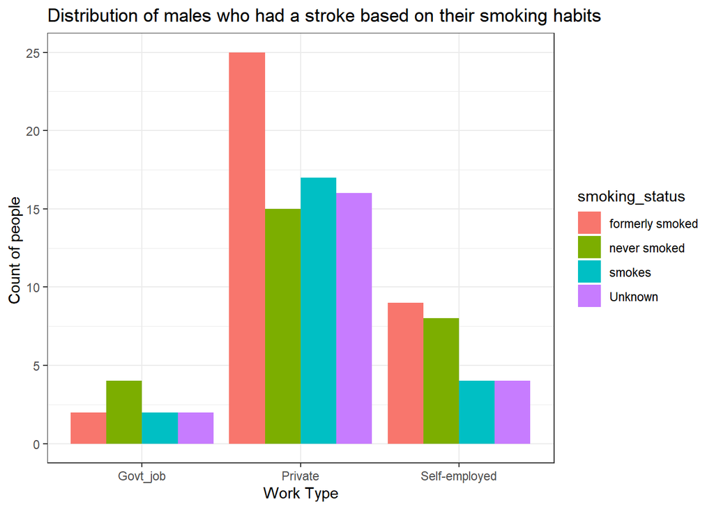

```r
ggplot(stroke_1_male,aes(x=work_type, fill= smoking_status))+geom_bar(position = "dodge")+ggtitle("Distribution of males who had a stroke based on their smoking habits")+ theme_bw() + theme()+ xlab("Work Type") + ylab("Count of people ")
```

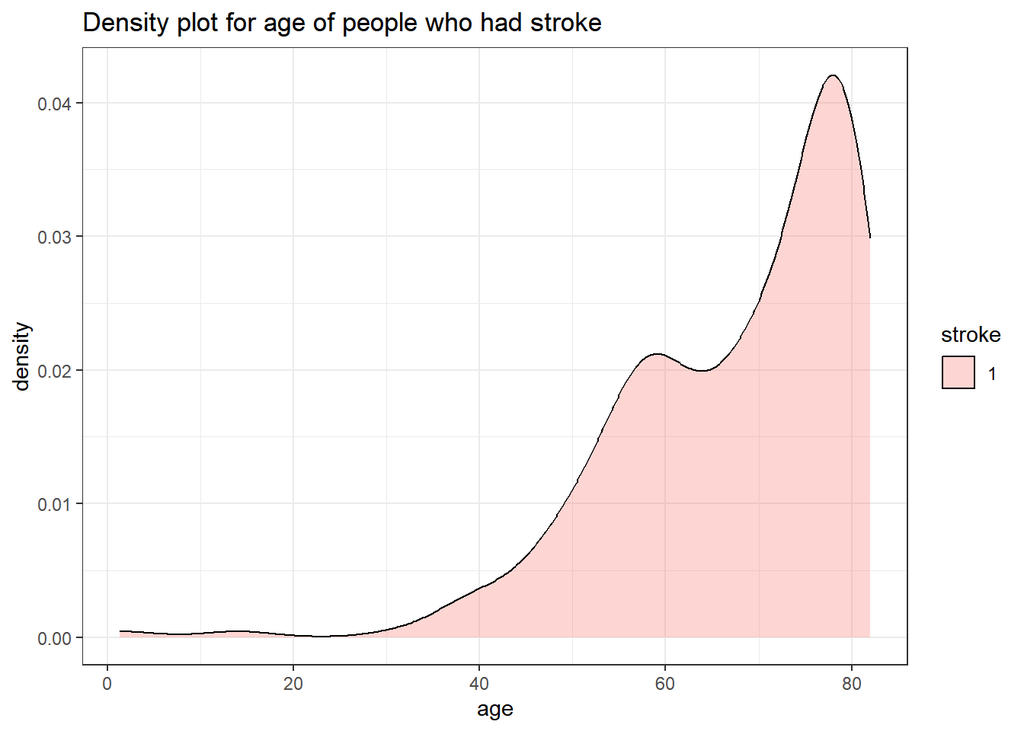

```r
ggplot(stroke_1, aes(x = age, fill=stroke))+ geom_density(alpha = 0.3)+ ggtitle("Density plot for age of people who had stroke")+ theme_bw() + theme()
```

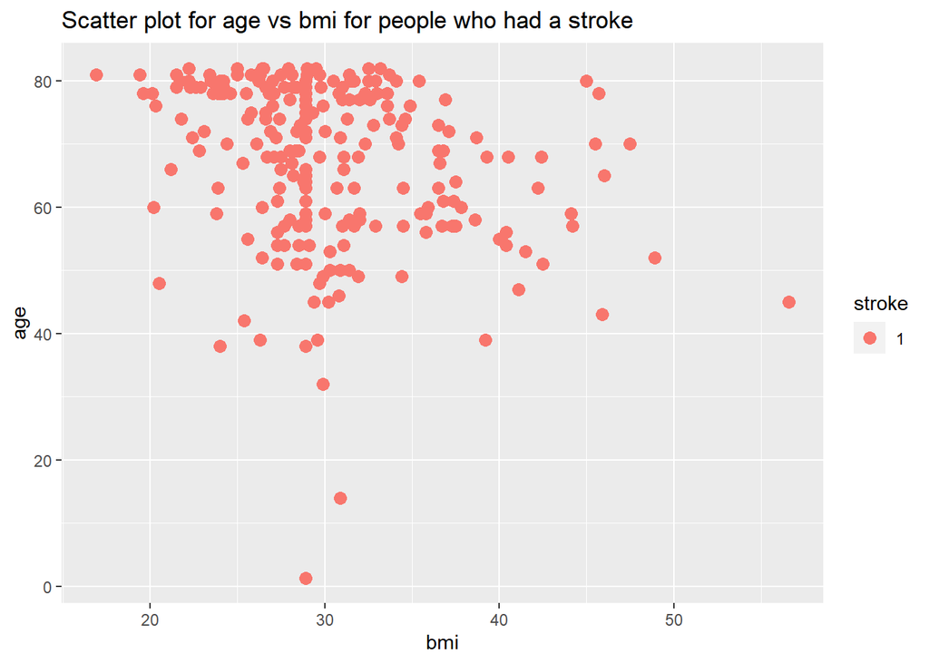

```r
ggplot(stroke_1, aes(x=bmi, y=age, color=stroke))+geom_point(size=3)+ ggtitle("Scatter plot for age vs bmi for people who had a stroke")
```

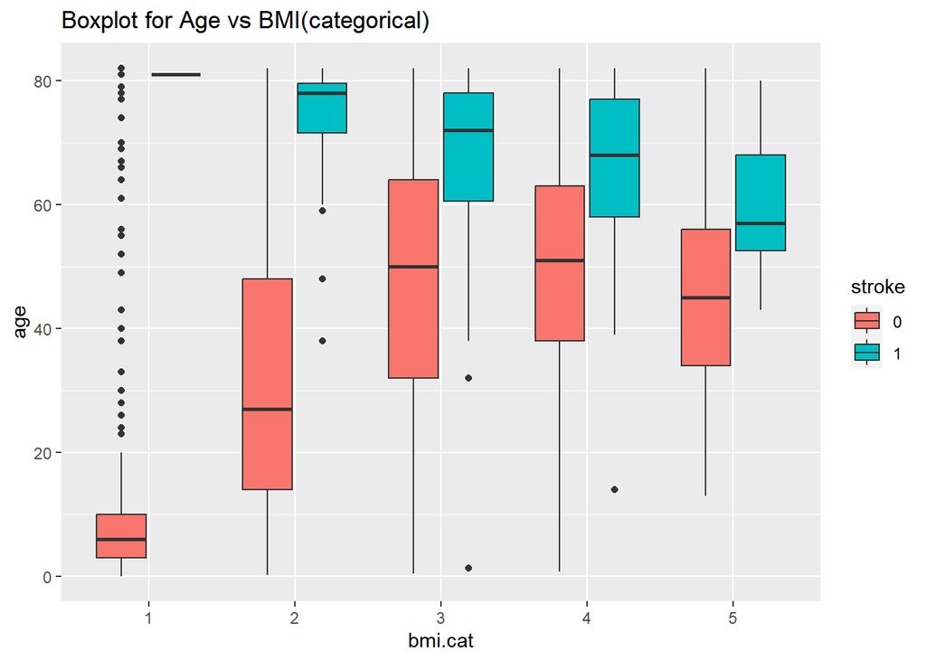

```r
ggplot(dat, aes(x=bmi.cat,y = age, fill=stroke))+geom_boxplot()+ ggtitle("Boxplot for Age vs BMI(categorical)")
```

Since the previous scatter plot provided a rough estimate of where the majority of the strokes occurred. We decided to divide these BMI into different categories based on the information provided by [Wikipedia](https://en.wikipedia.org/wiki/Body_mass_index)

The categories are encoded as:

- Underweight - BMI < 18.5
- Normal - BMI >= 18.5 and BMI <= 25
- Overweight - BMI >= 25.0 and BMI <= 30
- Obesity - BMI >= 30.0 and BMI < 40
- “Extreme” or Severe Obesity - BMI >= 40

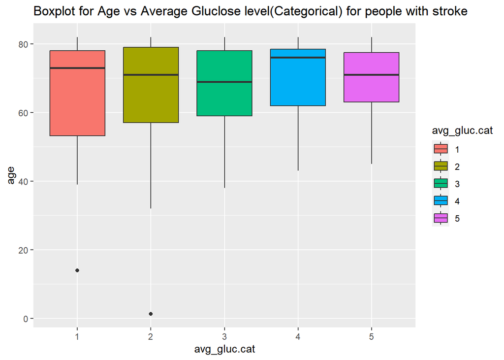

```r
stroke_1_dat = subset(dat, stroke==1 )
ggplot(stroke_1_dat, aes(fill=avg_gluc.cat, y = age, x = avg_gluc.cat))+ geom_boxplot()+ ggtitle("Boxplot for Age vs Average Gluclose level(Categorical) for people with stroke")
```

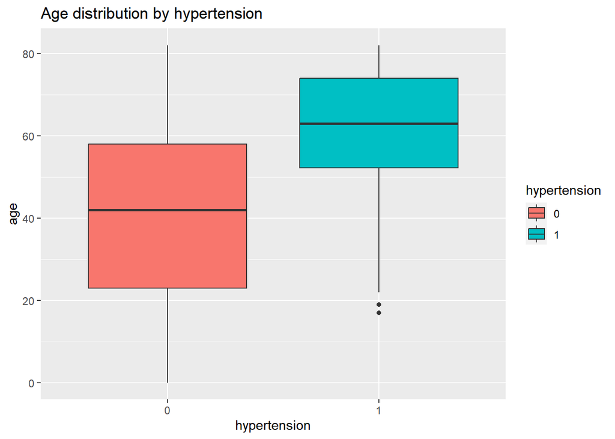

```r
ggplot(data = stroke_df, aes(x=as.character(hypertension), y=age, fill=hypertension)) +
    geom_boxplot() +
    labs(title="Age distribution by hypertension", x="hypertension", y="age")
```

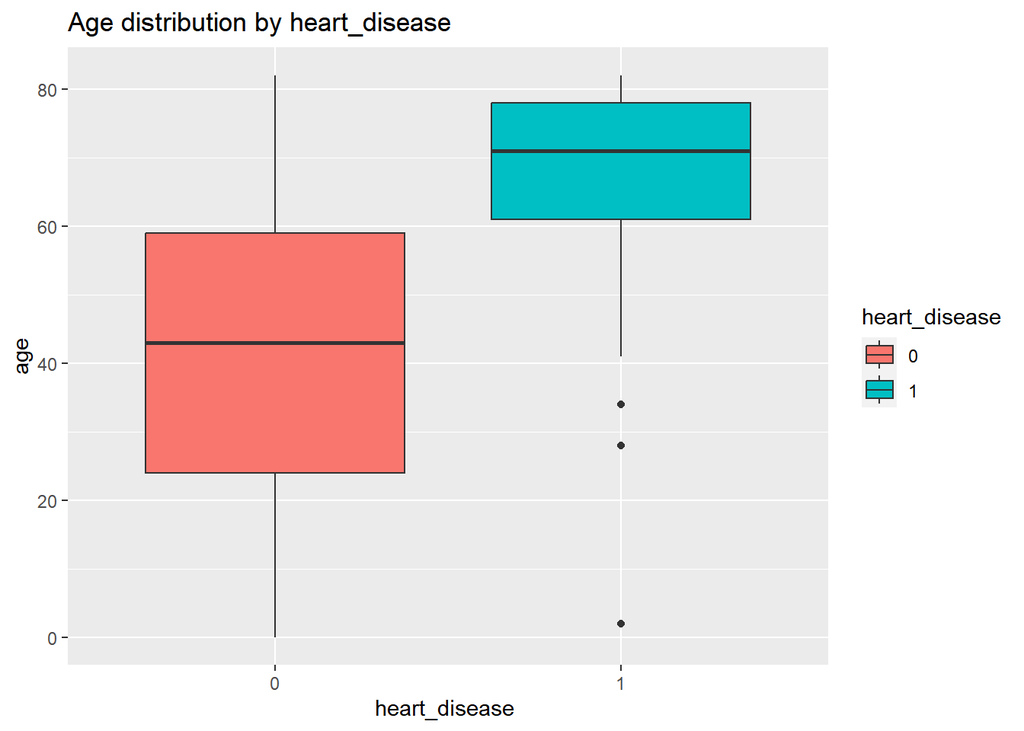

```r
ggplot(data = stroke_df, aes(x=as.character(heart_disease ), y=age, fill=heart_disease)) +
    geom_boxplot() +
    labs(title="Age distribution by heart_disease ", x="heart_disease ", y="age")
```

```r
ctest4 = chisq.test(stroke_df$heart_disease, stroke_df$stroke)
ctest4
```

```
##
##  Pearson's Chi-squared test with Yates' continuity correction
##
## data:  stroke_df$heart_disease and stroke_df$stroke
## X-squared = 90.229, df = 1, p-value < 2.2e-16
```

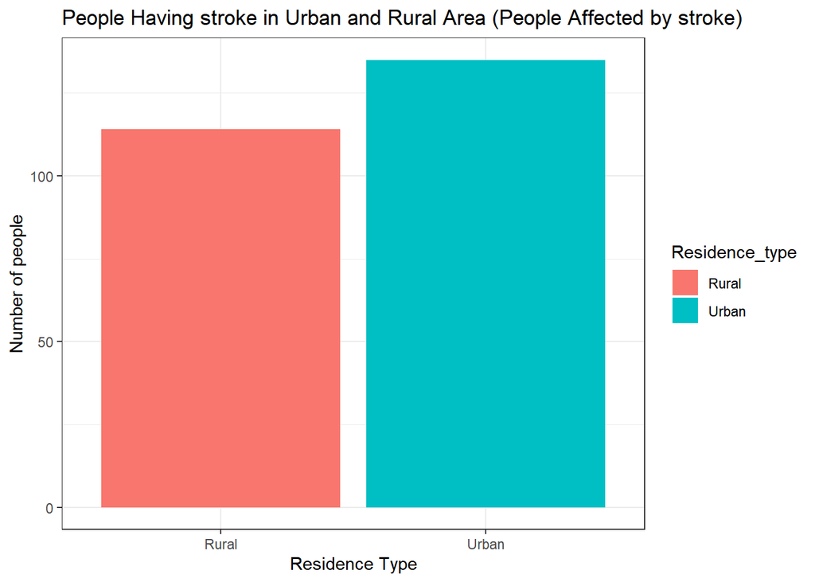

```r
ggplot(stroke_1_dat, aes(x=Residence_type,fill=Residence_type))+geom_bar(position = "dodge")+ggtitle("People Having stroke in Urban and Rural Area (People Affected by stroke)")+ theme_bw() +theme()+ xlab("Residence Type") + ylab("Number of people")
```

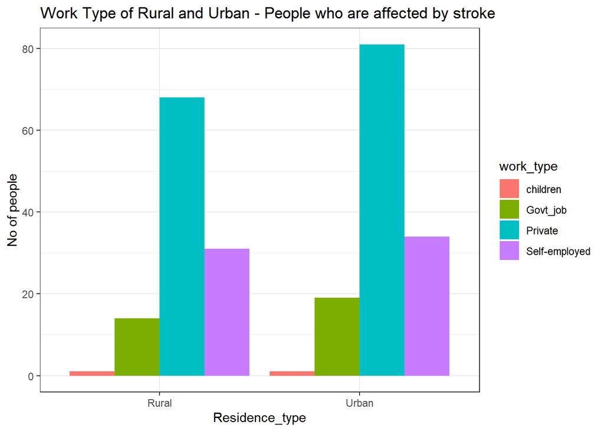

```r
ggplot(stroke_1_dat,aes(x=Residence_type,fill=work_type))+geom_bar(position="dodge")+ggtitle("Work Type of Rural and Urban - People who are affected by stroke ")+theme()+theme_bw()+ylab("No of people")
```

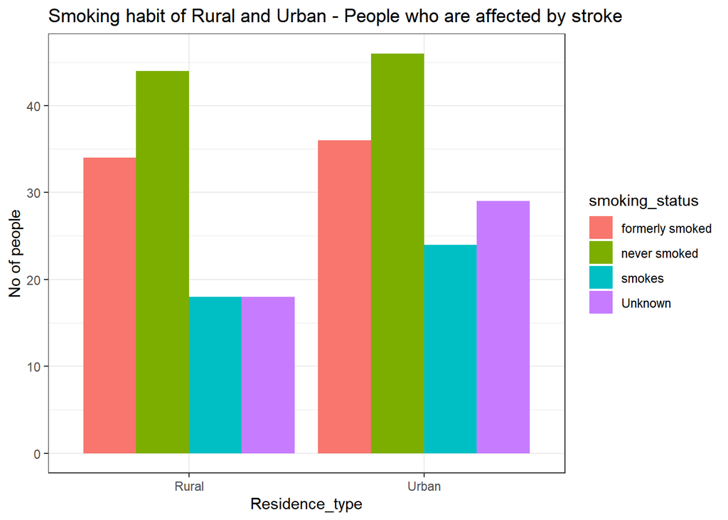

```r
ggplot(stroke_1_dat,aes(x=Residence_type,fill=smoking_status))+geom_bar(position="dodge")+ggtitle("Smoking habit of Rural and Urban - People who are affected by stroke ")+theme()+theme_bw()+ylab("No of people")
```

# 4 Modeling

## 4.1 Using the under and over sampling method (both)

```r
set.seed(80)
# In the train data we are using under and oversampling to address the class imbalance problem
ind <- sample(2, nrow(stroke_df), replace = TRUE, prob = c(0.7, 0.3))
train <- stroke_df[ind==1,]
test <- stroke_df[ind==2,]

dim(train)
```

```
## [1] 3582   11
```

```r
dim(test)
```

```
## [1] 1527   11
```

```r
train <- ovun.sample(stroke~., data=train, method = "both",p = 0.5,seed = 222)$data

r<-table(train$stroke)
paste("Seeing if the class imabalance is fixed")
```

```
## [1] "Seeing if the class imabalance is fixed"
```

```r
r
```

```
##
##    0    1
## 1773 1809
```

```r
str(test)
```

```
## 'data.frame':    1527 obs. of  11 variables:
##  $ gender           : Factor w/ 3 levels "Female","Male",..: 2 1 2 2 1 2 2 2 2 1 ...
##  $ age              : num  80 78 78 57 65 57 74 60 76 58 ...
##  $ hypertension     : Factor w/ 2 levels "0","1": 1 1 1 1 1 2 1 2 2 1 ...
##  $ heart_disease    : Factor w/ 2 levels "0","1": 2 1 2 2 1 1 1 1 1 1 ...
##  $ ever_married     : Factor w/ 2 levels "No","Yes": 2 2 2 1 2 2 2 2 2 2 ...
##  $ work_type        : Factor w/ 5 levels "children","Govt_job",..: 4 4 4 2 4 4 4 2 4 4 ...
##  $ Residence_type   : Factor w/ 2 levels "Rural","Urban": 1 2 2 2 1 2 1 2 1 2 ...
##  $ avg_glucose_level: num  105.9 58.6 219.8 217.1 101 ...
##  $ bmi              : num  32.5 24.2 28.9 28.9 28.2 ...
##  $ smoking_status   : Factor w/ 4 levels "formerly smoked",..: 2 4 4 4 1 3 1 3 2 1 ...
##  $ stroke           : Factor w/ 2 levels "0","1": 2 2 2 2 2 2 2 2 2 2 ...
```

# 5 Feature Selection

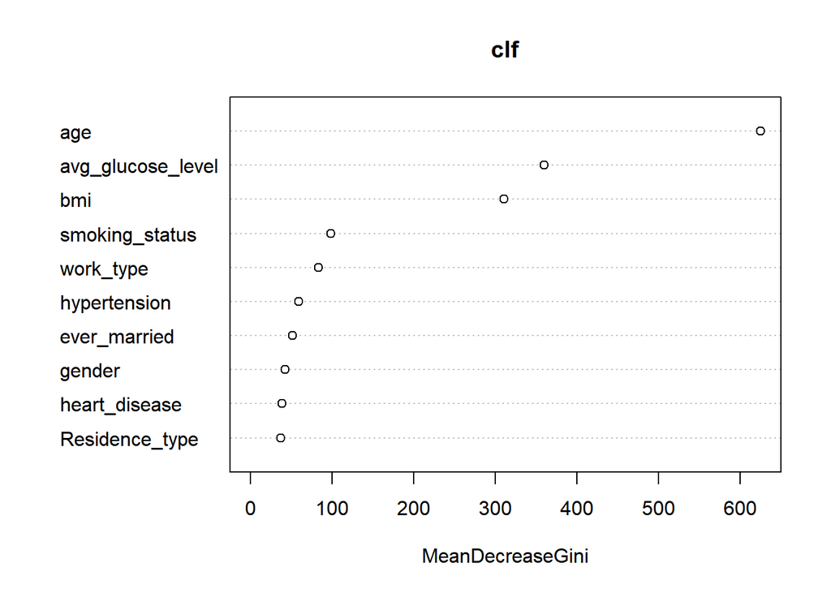

```r
clf = randomForest(x = train[-11],
                             y = train$stroke,
                             ntree = 500)

# Predicting the Test set results
y_pred = predict(clf, newdata = test[-11])

# Confusion Matrix
confusion = table(test$stroke, y_pred)
varImpPlot(clf)
```

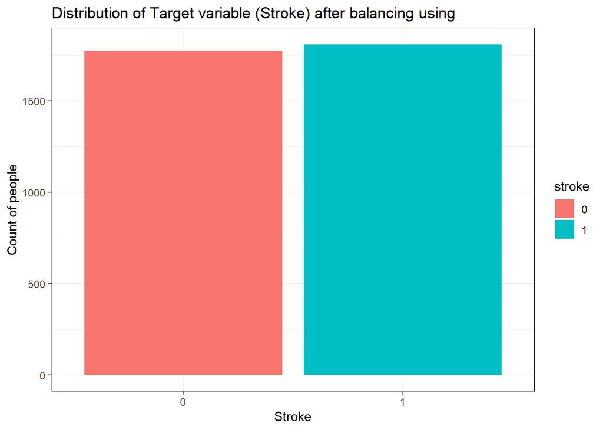

```r
ggplot(train, aes(x=stroke,fill=stroke))+geom_bar()+ggtitle("Distribution of Target variable (Stroke) after balancing using ")+ theme_bw() + theme()+ xlab("Stroke") + ylab("Count of people")
```

```r
str(test)
```

```
## 'data.frame':    1527 obs. of  11 variables:
##  $ gender           : Factor w/ 3 levels "Female","Male",..: 2 1 2 2 1 2 2 2 2 1 ...
##  $ age              : num  80 78 78 57 65 57 74 60 76 58 ...
##  $ hypertension     : Factor w/ 2 levels "0","1": 1 1 1 1 1 2 1 2 2 1 ...
##  $ heart_disease    : Factor w/ 2 levels "0","1": 2 1 2 2 1 1 1 1 1 1 ...
##  $ ever_married     : Factor w/ 2 levels "No","Yes": 2 2 2 1 2 2 2 2 2 2 ...
##  $ work_type        : Factor w/ 5 levels "children","Govt_job",..: 4 4 4 2 4 4 4 2 4 4 ...
##  $ Residence_type   : Factor w/ 2 levels "Rural","Urban": 1 2 2 2 1 2 1 2 1 2 ...
##  $ avg_glucose_level: num  105.9 58.6 219.8 217.1 101 ...
##  $ bmi              : num  32.5 24.2 28.9 28.9 28.2 ...
##  $ smoking_status   : Factor w/ 4 levels "formerly smoked",..: 2 4 4 4 1 3 1 3 2 1 ...
##  $ stroke           : Factor w/ 2 levels "0","1": 2 2 2 2 2 2 2 2 2 2 ...
```

### 5.0.1 LOGIT

```r
set.seed(123)
logit  <- glm(stroke ~., family=binomial (link="logit"), data=train)
predlogit <- predict(logit, newdata=test[-11], type="response")
confusion <- table(test$stroke, predlogit >= 0.5)
confusion
```

```
##
##     FALSE TRUE
##   0  1085  374
##   1    10   58
```

```r
pred = ifelse(predlogit>=0.5,1,0)
pred = as.factor(pred)
confusion1= confusionMatrix(pred,test$stroke,mode= "everything")
confusion1
```

```
## Confusion Matrix and Statistics
##
##           Reference
## Prediction    0    1
##          0 1085   10
##          1  374   58
##
##                Accuracy : 0.7485
##                  95% CI : (0.726, 0.7701)
##     No Information Rate : 0.9555
##     P-Value [Acc > NIR] : 1
##
##                   Kappa : 0.168
##
##  Mcnemar's Test P-Value : <2e-16
##
##             Sensitivity : 0.7437
##             Specificity : 0.8529
##          Pos Pred Value : 0.9909
##          Neg Pred Value : 0.1343
##               Precision : 0.9909
##                  Recall : 0.7437
##                      F1 : 0.8496
##              Prevalence : 0.9555
##          Detection Rate : 0.7105
##    Detection Prevalence : 0.7171
##       Balanced Accuracy : 0.7983
##
##        'Positive' Class : 0
##
```

```r
# Eval Metric
TN =confusion[1,1]
TP =confusion[2,2]
FP =confusion[1,2]
FN =confusion[2,1]
precision =(TP)/(TP+FP)
recall_score =(TP)/(TP+FN)
f1_score=2*((precision*recall_score)/(precision+recall_score))
accuracy_model  =(TP+TN)/(TP+TN+FP+FN)
print(paste('Accuracy for test', accuracy_model))
```

```
## [1] "Accuracy for test 0.74852652259332"
```

```r
print(paste('recall_score for test', recall_score))
```

```
## [1] "recall_score for test 0.852941176470588"
```

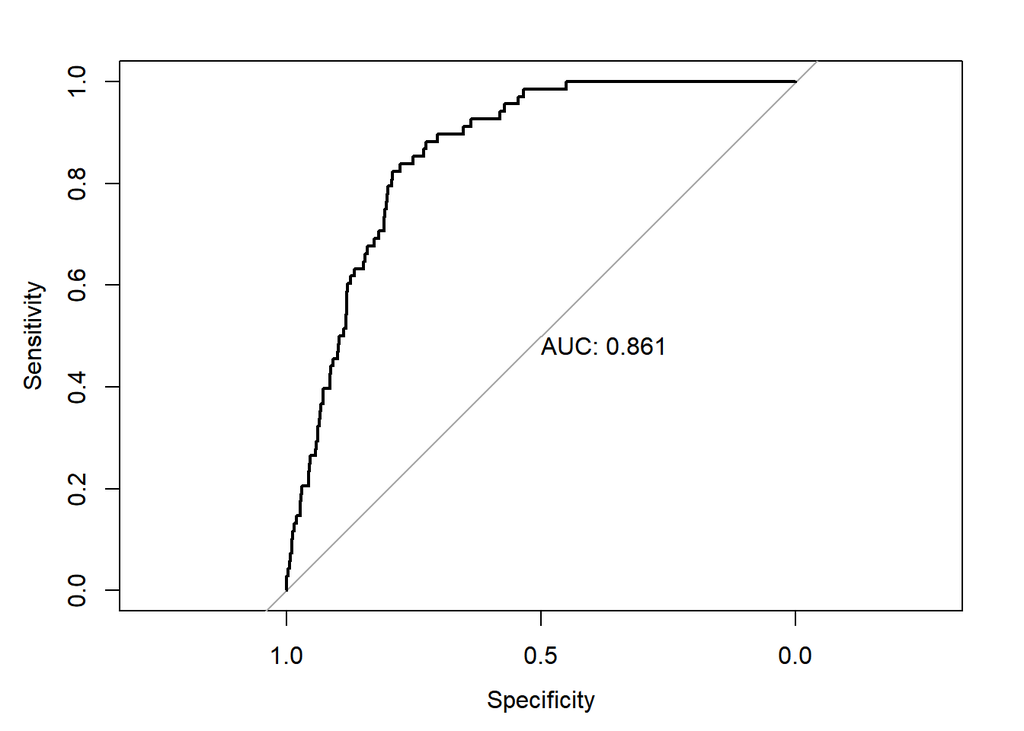

```r
test_prob = predict(logit, test[-11], type = "response")

test_roc = roc(test$stroke ~ test_prob, plot = TRUE, print.auc = TRUE)
```

```r
test_roc
```

```
##
## Call:
## roc.formula(formula = test$stroke ~ test_prob, plot = TRUE, print.auc = TRUE)
##
## Data: test_prob in 1459 controls (test$stroke 0) < 68 cases (test$stroke 1).
## Area under the curve: 0.861
```

#### 5.0.1.1 LOGIT with feature selected variables

```r
library(ROSE)
set.seed(1234)
train_fe = subset(train, select = c(age,avg_glucose_level,work_type,hypertension,smoking_status,bmi,stroke))
test_fe = subset(test, select = c(age,avg_glucose_level,work_type,hypertension,smoking_status,bmi,stroke))
str(train_fe[-7])
```

```
## 'data.frame':    3582 obs. of  6 variables:
##  $ age              : num  61 32 12 66 47 82 25 56 62 20 ...
##  $ avg_glucose_level: num  153.4 64 80.9 66.2 72.2 ...
##  $ work_type        : Factor w/ 5 levels "children","Govt_job",..: 2 4 1 5 4 5 4 4 5 2 ...
##  $ hypertension     : Factor w/ 2 levels "0","1": 2 1 1 1 1 2 1 1 1 1 ...
##  $ smoking_status   : Factor w/ 4 levels "formerly smoked",..: 2 3 4 2 4 1 2 2 2 1 ...
##  $ bmi              : num  38.8 23.8 20.1 37.5 33 27 24.5 23.4 24.8 27.9 ...
```

```r
logit  <- glm(stroke ~., family=binomial (link="logit"), data=train_fe)
predlogit <- predict(logit, newdata=test_fe[-7], type="response")
confusion <- table(test_fe$stroke, predlogit >= 0.5)
confusion
```

```
##
##     FALSE TRUE
##   0  1072  387
##   1    10   58
```

```r
pred = ifelse(predlogit>=0.5,1,0)
pred = as.factor(pred)
confusion1= confusionMatrix(pred,test_fe$stroke,mode= "everything")
confusion1
```

```
## Confusion Matrix and Statistics
##
##           Reference
## Prediction    0    1
##          0 1072   10
##          1  387   58
##
##                Accuracy : 0.74
##                  95% CI : (0.7172, 0.7619)
##     No Information Rate : 0.9555
##     P-Value [Acc > NIR] : 1
##
##                   Kappa : 0.1613
##
##  Mcnemar's Test P-Value : <2e-16
##
##             Sensitivity : 0.7347
##             Specificity : 0.8529
##          Pos Pred Value : 0.9908
##          Neg Pred Value : 0.1303
##               Precision : 0.9908
##                  Recall : 0.7347
##                      F1 : 0.8438
##              Prevalence : 0.9555
##          Detection Rate : 0.7020
##    Detection Prevalence : 0.7086
##       Balanced Accuracy : 0.7938
##
##        'Positive' Class : 0
##
```

```r
# Eval Metric
TN =confusion[1,1]
TP =confusion[2,2]
FP =confusion[1,2]
FN =confusion[2,1]
precision =(TP)/(TP+FP)
recall_score =(TP)/(TP+FN)
f1_score=2*((precision*recall_score)/(precision+recall_score))
accuracy_model  =(TP+TN)/(TP+TN+FP+FN)
print(paste('Accuracy for test', accuracy_model))
```

```
## [1] "Accuracy for test 0.740013097576948"
```

```r
print(paste('recall_score for test', recall_score))
```

```
## [1] "recall_score for test 0.852941176470588"
```

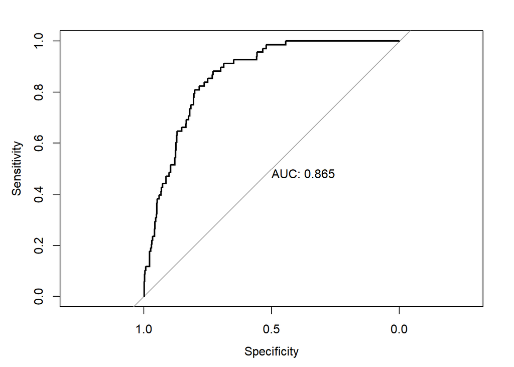

```r
test_prob = predict(logit, test_fe[-7], type = "response")

test_roc = roc(test_fe$stroke ~ test_prob, plot = TRUE, print.auc = TRUE)
```

```r
test_roc
```

```
##
## Call:
## roc.formula(formula = test_fe$stroke ~ test_prob, plot = TRUE,     print.auc = TRUE)
##
## Data: test_prob in 1459 controls (test_fe$stroke 0) < 68 cases (test_fe$stroke 1).
## Area under the curve: 0.8649
```

### 5.0.2 Decision Tree

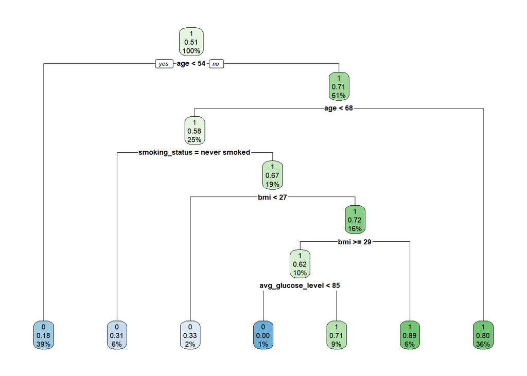

```r
fit <- rpart(stroke~ ., data = train , method = 'class')
rpart.plot(fit, extra = 106)
```

```r
predict_unseen <-predict(fit, test[-11], type = 'class')
confusion <- table(test$stroke, predict_unseen)
confusion
```

```
##    predict_unseen
##        0    1
##   0 1154  305
##   1   14   54
```

```r
confusion1= confusionMatrix(predict_unseen,test$stroke,mode= "everything")
confusion1
```

```
## Confusion Matrix and Statistics
##
##           Reference
## Prediction    0    1
##          0 1154   14
##          1  305   54
##
##                Accuracy : 0.7911
##                  95% CI : (0.7698, 0.8112)
##     No Information Rate : 0.9555
##     P-Value [Acc > NIR] : 1
##
##                   Kappa : 0.1925
##
##  Mcnemar's Test P-Value : <2e-16
##
##             Sensitivity : 0.7910
##             Specificity : 0.7941
##          Pos Pred Value : 0.9880
##          Neg Pred Value : 0.1504
##               Precision : 0.9880
##                  Recall : 0.7910
##                      F1 : 0.8786
##              Prevalence : 0.9555
##          Detection Rate : 0.7557
##    Detection Prevalence : 0.7649
##       Balanced Accuracy : 0.7925
##
##        'Positive' Class : 0
##
```

```r
# Eval Metric
TN =confusion[1,1]
TP =confusion[2,2]
FP =confusion[1,2]
FN =confusion[2,1]
precision =(TP)/(TP+FP)
recall_score =(TP)/(TP+FN)
f1_score=2*((precision*recall_score)/(precision+recall_score))
accuracy_model  =(TP+TN)/(TP+TN+FP+FN)
print(paste('Accuracy for test', accuracy_model))
```

```
## [1] "Accuracy for test 0.79109364767518"
```

```r
print(paste('recall_score for test', recall_score))
```

```
## [1] "recall_score for test 0.794117647058823"
```

#### 5.0.2.1 Decision Tree with feature selection

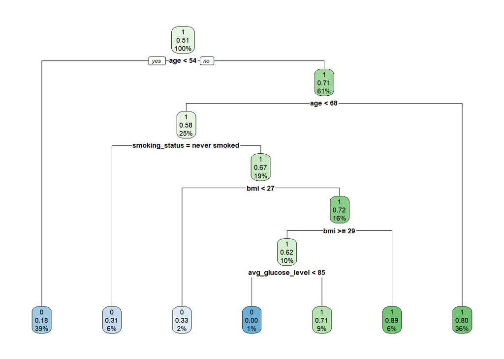

```r
fit <- rpart(stroke~ ., data = train_fe , method = 'class')
rpart.plot(fit, extra = 106)
```

```r
predict_unseen <-predict(fit, test_fe[-7], type = 'class')
confusion <- table(test_fe$stroke, predict_unseen)
confusion
```

```
##    predict_unseen
##        0    1
##   0 1154  305
##   1   14   54
```

```r
confusion1= confusionMatrix(predict_unseen,test_fe$stroke,mode= "everything")
confusion1
```

```
## Confusion Matrix and Statistics
##
##           Reference
## Prediction    0    1
##          0 1154   14
##          1  305   54
##
##                Accuracy : 0.7911
##                  95% CI : (0.7698, 0.8112)
##     No Information Rate : 0.9555
##     P-Value [Acc > NIR] : 1
##
##                   Kappa : 0.1925
##
##  Mcnemar's Test P-Value : <2e-16
##
##             Sensitivity : 0.7910
##             Specificity : 0.7941
##          Pos Pred Value : 0.9880
##          Neg Pred Value : 0.1504
##               Precision : 0.9880
##                  Recall : 0.7910
##                      F1 : 0.8786
##              Prevalence : 0.9555
##          Detection Rate : 0.7557
##    Detection Prevalence : 0.7649
##       Balanced Accuracy : 0.7925
##
##        'Positive' Class : 0
##
```

```r
# Eval Metric
TN =confusion[1,1]
TP =confusion[2,2]
FP =confusion[1,2]
FN =confusion[2,1]
precision =(TP)/(TP+FP)
recall_score =(TP)/(TP+FN)
f1_score=2*((precision*recall_score)/(precision+recall_score))
accuracy_model  =(TP+TN)/(TP+TN+FP+FN)
print(paste('Accuracy for test', accuracy_model))
```

```
## [1] "Accuracy for test 0.79109364767518"
```

```r
print(paste('recall_score for test', recall_score))
```

```
## [1] "recall_score for test 0.794117647058823"
```

### 5.0.3 tuned decision tree

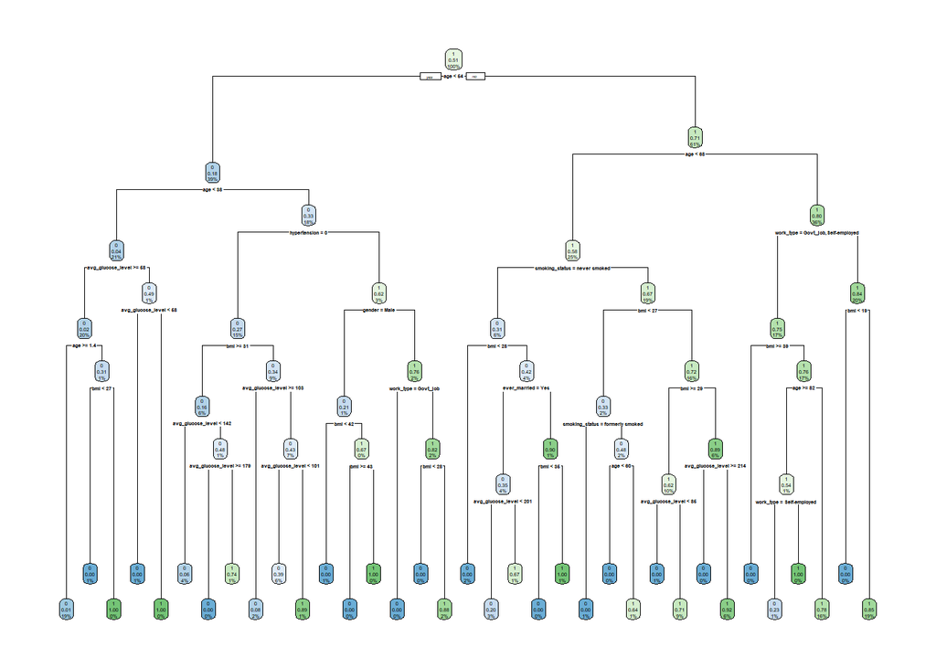

```r
control <- rpart.control(minsplit = 5,
    minbucket = round(5 / 3),
    maxdepth = 6,
    cp = 0)
tune_fit <- rpart(stroke~., data = train , method = 'class', control = control)
rpart.plot(tune_fit, extra = 106)
```

```r
predict_unseen1 <-predict(tune_fit, test[-11], type = 'class')
confusion <- table(test$stroke, predict_unseen1)
confusion
```

```
##    predict_unseen1
##        0    1
##   0 1120  339
##   1   13   55
```

```r
confusion1= confusionMatrix(predict_unseen1,test$stroke,mode= "everything")
confusion1
```

```
## Confusion Matrix and Statistics
##
##           Reference
## Prediction    0    1
##          0 1120   13
##          1  339   55
##
##                Accuracy : 0.7695
##                  95% CI : (0.7475, 0.7904)
##     No Information Rate : 0.9555
##     P-Value [Acc > NIR] : 1
##
##                   Kappa : 0.1755
##
##  Mcnemar's Test P-Value : <2e-16
##
##             Sensitivity : 0.7676
##             Specificity : 0.8088
##          Pos Pred Value : 0.9885
##          Neg Pred Value : 0.1396
##               Precision : 0.9885
##                  Recall : 0.7676
##                      F1 : 0.8642
##              Prevalence : 0.9555
##          Detection Rate : 0.7335
##    Detection Prevalence : 0.7420
##       Balanced Accuracy : 0.7882
##
##        'Positive' Class : 0
##
```

```r
# Eval Metric
TN =confusion[1,1]
TP =confusion[2,2]
FP =confusion[1,2]
FN =confusion[2,1]
precision =(TP)/(TP+FP)
recall_score =(TP)/(TP+FN)
f1_score=2*((precision*recall_score)/(precision+recall_score))
accuracy_model  =(TP+TN)/(TP+TN+FP+FN)
print(paste('Accuracy for test', accuracy_model))
```

```
## [1] "Accuracy for test 0.769482645710544"
```

```r
print(paste('recall_score for test', recall_score))
```

```
## [1] "recall_score for test 0.808823529411765"
```

#### 5.0.3.1 tuned decision tree with feature selection

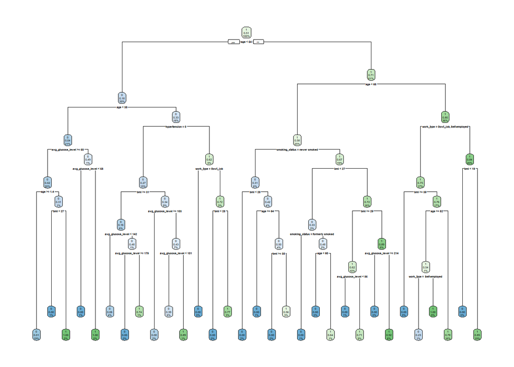

```r
control <- rpart.control(minsplit = 5,
    minbucket = round(5 / 3),
    maxdepth = 6,
    cp = 0)
tune_fit <- rpart(stroke~., data = train_fe , method = 'class', control = control)
rpart.plot(tune_fit, extra = 106)
```

```r
predict_unseen1 <-predict(tune_fit, test_fe[-7], type = 'class')
confusion <- table(test_fe$stroke, predict_unseen1)
confusion
```

```
##    predict_unseen1
##        0    1
##   0 1075  384
##   1   12   56
```

```r
confusion1= confusionMatrix(predict_unseen1,test_fe$stroke,mode= "everything")
confusion1
```

```
## Confusion Matrix and Statistics
##
##           Reference
## Prediction    0    1
##          0 1075   12
##          1  384   56
##
##                Accuracy : 0.7407
##                  95% CI : (0.7179, 0.7625)
##     No Information Rate : 0.9555
##     P-Value [Acc > NIR] : 1
##
##                   Kappa : 0.1553
##
##  Mcnemar's Test P-Value : <2e-16
##
##             Sensitivity : 0.7368
##             Specificity : 0.8235
##          Pos Pred Value : 0.9890
##          Neg Pred Value : 0.1273
##               Precision : 0.9890
##                  Recall : 0.7368
##                      F1 : 0.8445
##              Prevalence : 0.9555
##          Detection Rate : 0.7040
##    Detection Prevalence : 0.7119
##       Balanced Accuracy : 0.7802
##
##        'Positive' Class : 0
##
```

```r
# Eval Metric
TN =confusion[1,1]
TP =confusion[2,2]
FP =confusion[1,2]
FN =confusion[2,1]
precision =(TP)/(TP+FP)
recall_score =(TP)/(TP+FN)
f1_score=2*((precision*recall_score)/(precision+recall_score))
accuracy_model  =(TP+TN)/(TP+TN+FP+FN)
print(paste('Accuracy for test', accuracy_model))
```

```
## [1] "Accuracy for test 0.740667976424361"
```

```r
print(paste('recall_score for test', recall_score))
```

```
## [1] "recall_score for test 0.823529411764706"
```

### 5.0.4 Random Forest

```r
classifier_RF = randomForest(x = train[-11],
                             y = train$stroke,
                             ntree = 500)

classifier_RF
```

```
##
## Call:
##  randomForest(x = train[-11], y = train$stroke, ntree = 500)
##                Type of random forest: classification
##                      Number of trees: 500
## No. of variables tried at each split: 3
##
##         OOB estimate of  error rate: 1.93%
## Confusion matrix:
##      0    1 class.error
## 0 1704   69  0.03891709
## 1    0 1809  0.00000000
```

```r
# Predicting the Test set results
y_pred = predict(classifier_RF, newdata = test[-11])

# Confusion Matrix
confusion = table(test$stroke, y_pred)
confusion
```

```
##    y_pred
##        0    1
##   0 1382   77
##   1   51   17
```

```r
confusion1= confusionMatrix(y_pred,test$stroke,mode= "everything")
confusion1
```

```
## Confusion Matrix and Statistics
##
##           Reference
## Prediction    0    1
##          0 1382   51
##          1   77   17
##
##                Accuracy : 0.9162
##                  95% CI : (0.9011, 0.9296)
##     No Information Rate : 0.9555
##     P-Value [Acc > NIR] : 1.00000
##
##                   Kappa : 0.1668
##
##  Mcnemar's Test P-Value : 0.02713
##
##             Sensitivity : 0.9472
##             Specificity : 0.2500
##          Pos Pred Value : 0.9644
##          Neg Pred Value : 0.1809
##               Precision : 0.9644
##                  Recall : 0.9472
##                      F1 : 0.9557
##              Prevalence : 0.9555
##          Detection Rate : 0.9050
##    Detection Prevalence : 0.9384
##       Balanced Accuracy : 0.5986
##
##        'Positive' Class : 0
##
```

```r
# Eval Metric
TN =confusion[1,1]
TP =confusion[2,2]
FP =confusion[1,2]
FN =confusion[2,1]
precision =(TP)/(TP+FP)
recall_score =(TP)/(TP+FN)
f1_score=2*((precision*recall_score)/(precision+recall_score))
accuracy_model  =(TP+TN)/(TP+TN+FP+FN)
print(paste('Accuracy for test', accuracy_model))
```

```
## [1] "Accuracy for test 0.916175507531107"
```

```r
print(paste('recall_score for test', recall_score))
```

```
## [1] "recall_score for test 0.25"
```

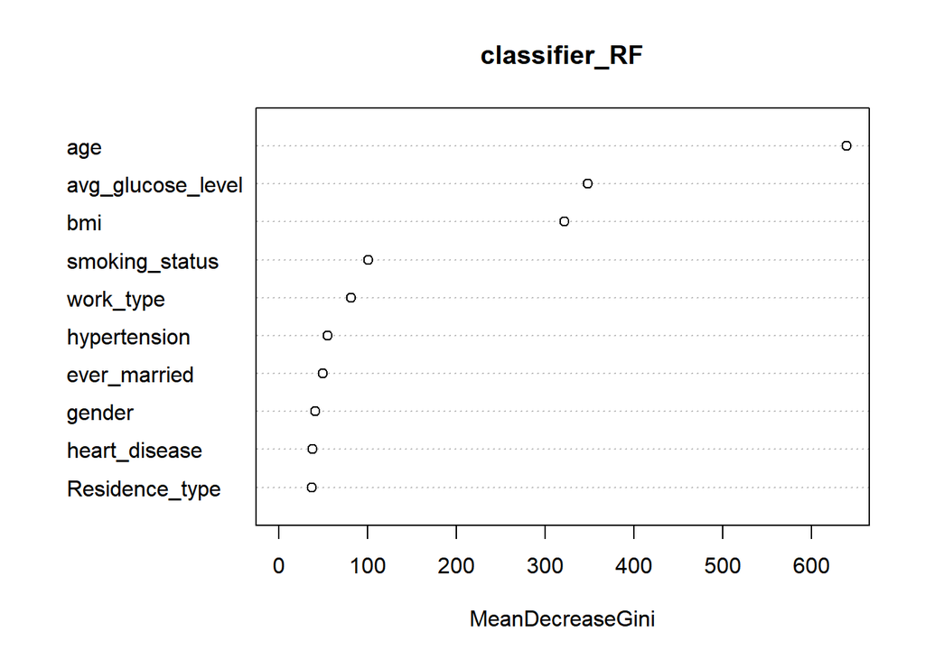

```r
varImpPlot(classifier_RF)
```

#### 5.0.4.1 Random forest with feature selection with 6 var

```r
train_fe1 = subset(train, select = c(age,avg_glucose_level,work_type,hypertension,smoking_status,bmi,stroke))
test_fe1 = subset(test, select = c(age,avg_glucose_level,work_type,hypertension,smoking_status,bmi,stroke))
dim(train_fe1)
```

```
## [1] 3582    7
```

```r
dim(test_fe1)
```

```
## [1] 1527    7
```

```r
classifier_RF = randomForest(x = train_fe1[-7],
                             y = train_fe1$stroke,
                             ntree = 500)

classifier_RF
```

```
##
## Call:
##  randomForest(x = train_fe1[-7], y = train_fe1$stroke, ntree = 500)
##                Type of random forest: classification
##                      Number of trees: 500
## No. of variables tried at each split: 2
##
##         OOB estimate of  error rate: 2.18%
## Confusion matrix:
##      0    1 class.error
## 0 1695   78  0.04399323
## 1    0 1809  0.00000000
```

```r
# Predicting the Test set results
y_pred = predict(classifier_RF, newdata = test_fe1[-7])

# Confusion Matrix
confusion = table(test_fe1$stroke, y_pred)
confusion
```

```
##    y_pred
##        0    1
##   0 1363   96
##   1   46   22
```

```r
confusion1= confusionMatrix(y_pred,test_fe1$stroke,mode= "everything")
confusion1
```

```
## Confusion Matrix and Statistics
##
##           Reference
## Prediction    0    1
##          0 1363   46
##          1   96   22
##
##                Accuracy : 0.907
##                  95% CI : (0.8913, 0.9211)
##     No Information Rate : 0.9555
##     P-Value [Acc > NIR] : 1
##
##                   Kappa : 0.1908
##
##  Mcnemar's Test P-Value : 3.923e-05
##
##             Sensitivity : 0.9342
##             Specificity : 0.3235
##          Pos Pred Value : 0.9674
##          Neg Pred Value : 0.1864
##               Precision : 0.9674
##                  Recall : 0.9342
##                      F1 : 0.9505
##              Prevalence : 0.9555
##          Detection Rate : 0.8926
##    Detection Prevalence : 0.9227
##       Balanced Accuracy : 0.6289
##
##        'Positive' Class : 0
##
```

```r
# Eval Metric
TN =confusion[1,1]
TP =confusion[2,2]
FP =confusion[1,2]
FN =confusion[2,1]
precision =(TP)/(TP+FP)
recall_score =(TP)/(TP+FN)
f1_score=2*((precision*recall_score)/(precision+recall_score))
accuracy_model  =(TP+TN)/(TP+TN+FP+FN)
print(paste('Accuracy for test', accuracy_model))
```

```
## [1] "Accuracy for test 0.907007203667322"
```

```r
print(paste('recall_score for test', recall_score))
```

```
## [1] "recall_score for test 0.323529411764706"
```

```r
varImp(classifier_RF)
```

```
##                     Overall
## age               681.67266
## avg_glucose_level 390.88800
## work_type          92.72263
## hypertension       58.90425
## smoking_status    101.55943
## bmi               355.77901
```

#### 5.0.4.2 Random Forest with feature selected variables

```r
classifier_RF1 = randomForest(x = train_fe[-7],
                             y = train_fe$stroke,
                             ntree = 500)

classifier_RF1
```

```
##
## Call:
##  randomForest(x = train_fe[-7], y = train_fe$stroke, ntree = 500)
##                Type of random forest: classification
##                      Number of trees: 500
## No. of variables tried at each split: 2
##
##         OOB estimate of  error rate: 1.98%
## Confusion matrix:
##      0    1 class.error
## 0 1702   71  0.04004512
## 1    0 1809  0.00000000
```

```r
# Predicting the Test set results
y_pred = predict(classifier_RF1, newdata = test_fe[-7])

# Confusion Matrix
confusion = table(test_fe$stroke, y_pred)
confusion
```

```
##    y_pred
##        0    1
##   0 1364   95
##   1   47   21
```

```r
confusion1= confusionMatrix(y_pred,test_fe$stroke,mode= "everything")
confusion1
```

```
## Confusion Matrix and Statistics
##
##           Reference
## Prediction    0    1
##          0 1364   47
##          1   95   21
##
##                Accuracy : 0.907
##                  95% CI : (0.8913, 0.9211)
##     No Information Rate : 0.9555
##     P-Value [Acc > NIR] : 1
##
##                   Kappa : 0.1824
##
##  Mcnemar's Test P-Value : 8.008e-05
##
##             Sensitivity : 0.9349
##             Specificity : 0.3088
##          Pos Pred Value : 0.9667
##          Neg Pred Value : 0.1810
##               Precision : 0.9667
##                  Recall : 0.9349
##                      F1 : 0.9505
##              Prevalence : 0.9555
##          Detection Rate : 0.8933
##    Detection Prevalence : 0.9240
##       Balanced Accuracy : 0.6219
##
##        'Positive' Class : 0
##
```

```r
# Eval Metric
TN =confusion[1,1]
TP =confusion[2,2]
FP =confusion[1,2]
FN =confusion[2,1]
precision =(TP)/(TP+FP)
recall_score =(TP)/(TP+FN)
f1_score=2*((precision*recall_score)/(precision+recall_score))
accuracy_model  =(TP+TN)/(TP+TN+FP+FN)
print(paste('Accuracy for test', accuracy_model))
```

```
## [1] "Accuracy for test 0.907007203667322"
```

```r
print(paste('recall_score for test', recall_score))
```

```
## [1] "recall_score for test 0.308823529411765"
```

## 5.1 Using ROSE techinque

```r
set.seed(1234)
trainIndex = sample(1:nrow(stroke_df), size=round(0.75*nrow(stroke_df)), replace=FALSE)
train1 <- stroke_df[trainIndex,]
test1  <- stroke_df[-trainIndex,]

dim(train1)
```

```
## [1] 3832   11
```

```r
dim(test1)
```

```
## [1] 1277   11
```

feature selection 1 data

```r
library(ROSE)
set.seed(1234)
train_fe = subset(train1, select = c(age,avg_glucose_level,work_type,hypertension,smoking_status,bmi,stroke))
test1_fe = subset(test1, select = c(age,avg_glucose_level,work_type,hypertension,smoking_status,bmi,stroke))
str(train_fe)
```

```
## 'data.frame':    3832 obs. of  7 variables:
##  $ age              : num  54 33 1.24 74 43 25 49 3 26 62 ...
##  $ avg_glucose_level: num  85.2 69.4 84.2 99.2 89.7 ...
##  $ work_type        : Factor w/ 5 levels "children","Govt_job",..: 4 4 1 5 5 4 4 1 2 5 ...
##  $ hypertension     : Factor w/ 2 levels "0","1": 1 1 1 1 1 1 1 1 1 2 ...
##  $ smoking_status   : Factor w/ 4 levels "formerly smoked",..: 2 2 4 2 1 2 2 4 1 2 ...
##  $ bmi              : num  50.2 47.8 19.2 22.1 23.5 35.8 32.1 15.8 29.2 34 ...
##  $ stroke           : Factor w/ 2 levels "0","1": 1 1 1 1 1 1 1 1 1 1 ...
```

```r
dim(test1_fe)
```

```
## [1] 1277    7
```

with feature selection rose split

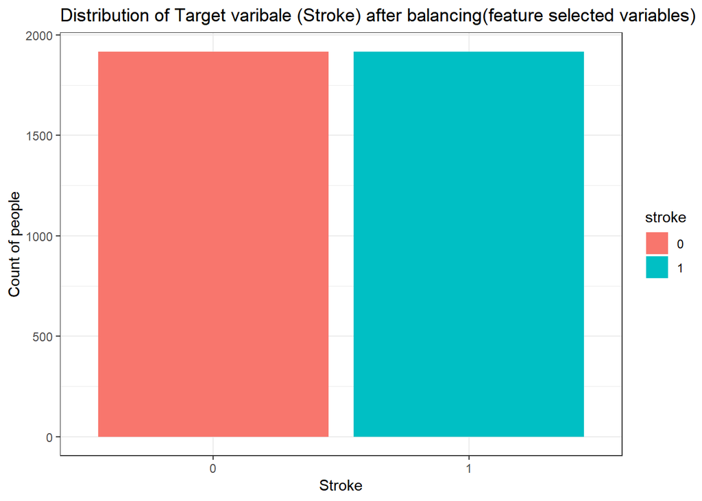

```r
set.seed(1234)

trainrose1<-ROSE(stroke~.,data=train_fe)$data

ggplot(trainrose1, aes(x=stroke,fill=stroke))+geom_bar()+ggtitle("Distribution of Target varibale (Stroke) after balancing(feature selected variables)")+ theme_bw() +  theme()+ xlab("Stroke") + ylab("Count of people")
```

```r
table(trainrose1$stroke)
```

```
##
##    0    1
## 1915 1917
```

Without feature selection data

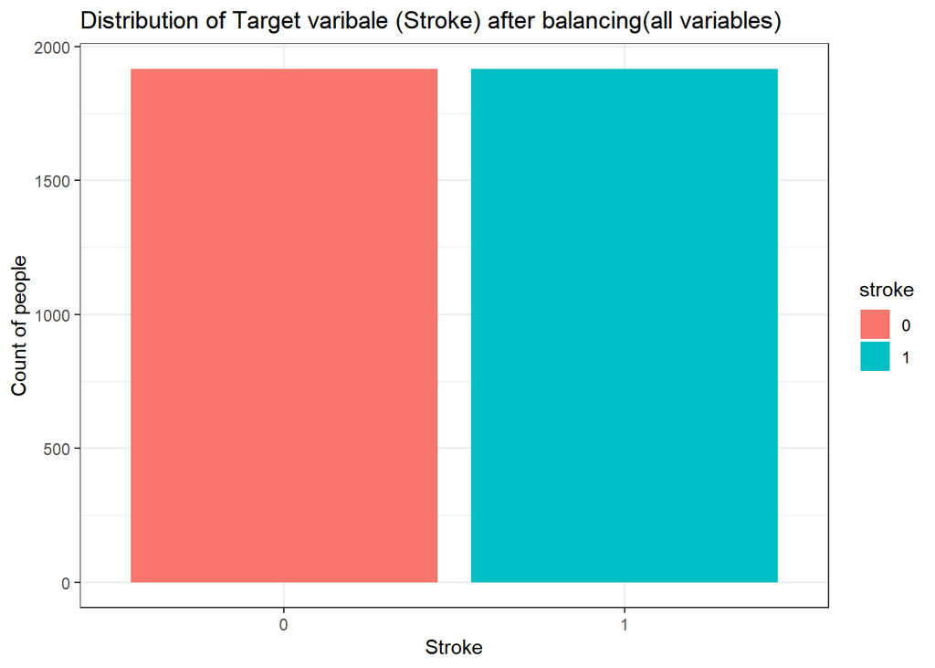

```r
set.seed(1234)

trainrose<-ROSE(stroke~.,data=train1)$data

ggplot(trainrose, aes(x=stroke,fill=stroke))+geom_bar()+ggtitle("Distribution of Target varibale (Stroke) after balancing(all variables)")+ theme_bw() +  theme()+ xlab("Stroke") + ylab("Count of people")
```

```r
trainrose$age = abs(trainrose$age)
trainrose$avg_glucose_level = abs(trainrose$avg_glucose_level)
summary(trainrose)
```

```
##     gender          age           hypertension heart_disease ever_married
##  Female:2178   Min.   : 0.05679   0:3150       0:3429        No : 905
##  Male  :1654   1st Qu.:41.34440   1: 682       1: 403        Yes:2927
##  Other :   0   Median :59.54328
##                Mean   :55.20210
##                3rd Qu.:73.58341
##                Max.   :99.35799
##          work_type    Residence_type avg_glucose_level       bmi
##  children     : 275   Rural:1858     Min.   :  0.1066   Min.   :11.61
##  Govt_job     : 451   Urban:1974     1st Qu.: 77.8501   1st Qu.:25.02
##  Never_worked :   3                  Median :101.5836   Median :28.86
##  Private      :2337                  Mean   :120.9033   Mean   :29.64
##  Self-employed: 766                  3rd Qu.:160.9005   3rd Qu.:33.42
##                                      Max.   :318.0114   Max.   :91.28
##          smoking_status stroke
##  formerly smoked: 824   0:1915
##  never smoked   :1507   1:1917
##  smokes         : 612
##  Unknown        : 889
##
##
```

```r
trainrose1$age = abs(trainrose1$age)
trainrose1$avg_glucose_level = abs(trainrose1$avg_glucose_level)
summary(trainrose1)
```

```
##       age           avg_glucose_level          work_type    hypertension
##  Min.   : 0.05679   Min.   :  0.1066   children     : 275   0:3150
##  1st Qu.:41.34440   1st Qu.: 77.8501   Govt_job     : 451   1: 682
##  Median :59.54328   Median :101.5836   Never_worked :   3
##  Mean   :55.20210   Mean   :120.9033   Private      :2337
##  3rd Qu.:73.58341   3rd Qu.:160.9005   Self-employed: 766
##  Max.   :99.35799   Max.   :318.0114
##          smoking_status      bmi        stroke
##  formerly smoked: 824   Min.   :11.61   0:1915
##  never smoked   :1507   1st Qu.:25.02   1:1917
##  smokes         : 612   Median :28.86
##  Unknown        : 889   Mean   :29.64
##                         3rd Qu.:33.42
##                         Max.   :91.28
```

```r
table(train_fe$stroke)
```

```
##
##    0    1
## 3631  201
```

```r
table(trainrose1$stroke)
```

```
##
##    0    1
## 1915 1917
```

```r
table(test1_fe$stroke)
```

```
##
##    0    1
## 1229   48
```

### 5.1.1 LOGIT Model

```r
set.seed(1234)
logitrose  <- glm(stroke ~., family=binomial (link="logit"), data=trainrose)
predlogitrose <- predict(logitrose, newdata=test1[-11], type="response")
confusion <- table(test1$stroke, predlogitrose >= 0.5)
confusion
```

```
##
##     FALSE TRUE
##   0   907  322
##   1     5   43
```

```r
pred = ifelse(predlogitrose>=0.5,1,0)
pred = as.factor(pred)
confusion1= confusionMatrix(pred,test1$stroke,mode= "everything")
confusion1
```

```
## Confusion Matrix and Statistics
##
##           Reference
## Prediction   0   1
##          0 907   5
##          1 322  43
##
##                Accuracy : 0.7439
##                  95% CI : (0.7191, 0.7677)
##     No Information Rate : 0.9624
##     P-Value [Acc > NIR] : 1
##
##                   Kappa : 0.1519
##
##  Mcnemar's Test P-Value : <2e-16
##
##             Sensitivity : 0.7380
##             Specificity : 0.8958
##          Pos Pred Value : 0.9945
##          Neg Pred Value : 0.1178
##               Precision : 0.9945
##                  Recall : 0.7380
##                      F1 : 0.8473
##              Prevalence : 0.9624
##          Detection Rate : 0.7103
##    Detection Prevalence : 0.7142
##       Balanced Accuracy : 0.8169
##
##        'Positive' Class : 0
##
```

```r
# Eval Metric
TN =confusion[1,1]
TP =confusion[2,2]
FP =confusion[1,2]
FN =confusion[2,1]
precision =(TP)/(TP+FP)
recall_score =(TP)/(TP+FN)
f1_score=2*((precision*recall_score)/(precision+recall_score))
accuracy_model  =(TP+TN)/(TP+TN+FP+FN)
print(paste('Accuracy for test', accuracy_model))
```

```
## [1] "Accuracy for test 0.743931088488645"
```

```r
print(paste('recall_score for test', recall_score))
```

```
## [1] "recall_score for test 0.895833333333333"
```

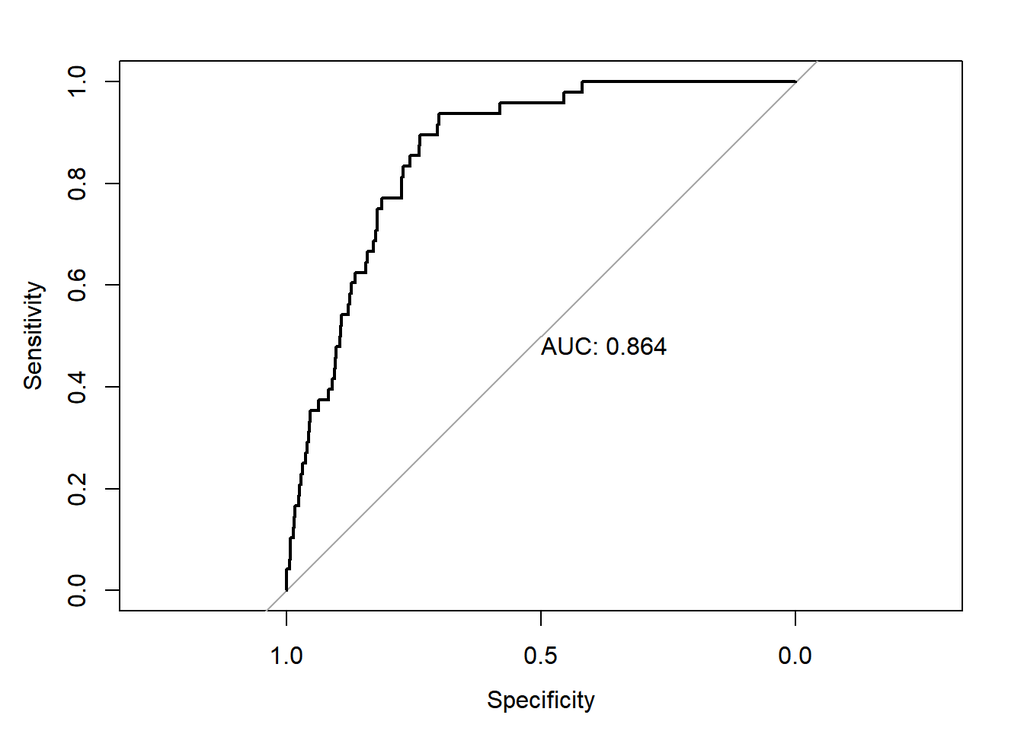

```r
test_prob = predict(logitrose, test1[-11], type = "response")

test_roc = roc(test1$stroke ~ test_prob, plot = TRUE, print.auc = TRUE)
```

```r
test_roc
```

```
##
## Call:
## roc.formula(formula = test1$stroke ~ test_prob, plot = TRUE,     print.auc = TRUE)
##
## Data: test_prob in 1229 controls (test1$stroke 0) < 48 cases (test1$stroke 1).
## Area under the curve: 0.8637
```

#### 5.1.1.1 LOGIT Model with feature selection

```r
set.seed(1234)
logitrose  <- glm(stroke ~., family=binomial (link="logit"), data=trainrose1)
predlogitrose <- predict(logitrose, newdata=test1_fe[-7], type="response")
confusion <- table(test1_fe$stroke, predlogitrose >= 0.5)
confusion
```

```
##
##     FALSE TRUE
##   0   907  322
##   1     6   42
```

```r
pred = ifelse(predlogitrose>=0.5,1,0)
pred = as.factor(pred)
confusion1= confusionMatrix(pred,test1_fe$stroke,mode= "everything")
confusion1
```

```
## Confusion Matrix and Statistics
##
##           Reference
## Prediction   0   1
##          0 907   6
##          1 322  42
##
##                Accuracy : 0.7431
##                  95% CI : (0.7183, 0.7669)
##     No Information Rate : 0.9624
##     P-Value [Acc > NIR] : 1
##
##                   Kappa : 0.1472
##
##  Mcnemar's Test P-Value : <2e-16
##
##             Sensitivity : 0.7380
##             Specificity : 0.8750
##          Pos Pred Value : 0.9934
##          Neg Pred Value : 0.1154
##               Precision : 0.9934
##                  Recall : 0.7380
##                      F1 : 0.8469
##              Prevalence : 0.9624
##          Detection Rate : 0.7103
##    Detection Prevalence : 0.7150
##       Balanced Accuracy : 0.8065
##
##        'Positive' Class : 0
##
```

```r
# Eval Metric
TN =confusion[1,1]
TP =confusion[2,2]
FP =confusion[1,2]
FN =confusion[2,1]
precision =(TP)/(TP+FP)
recall_score =(TP)/(TP+FN)
f1_score=2*((precision*recall_score)/(precision+recall_score))
accuracy_model  =(TP+TN)/(TP+TN+FP+FN)
print(paste('Accuracy for test', accuracy_model))
```

```
## [1] "Accuracy for test 0.743148003132341"
```

```r
print(paste('recall_score for test', recall_score))
```

```
## [1] "recall_score for test 0.875"
```

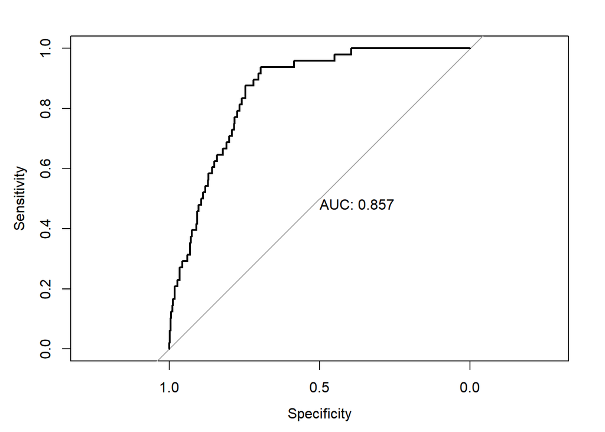

```r
test_prob = predict(logitrose, test1_fe[-11], type = "response")

test_roc = roc(test1_fe$stroke ~ test_prob, plot = TRUE, print.auc = TRUE)
```

### 5.1.2 DECISION TREE

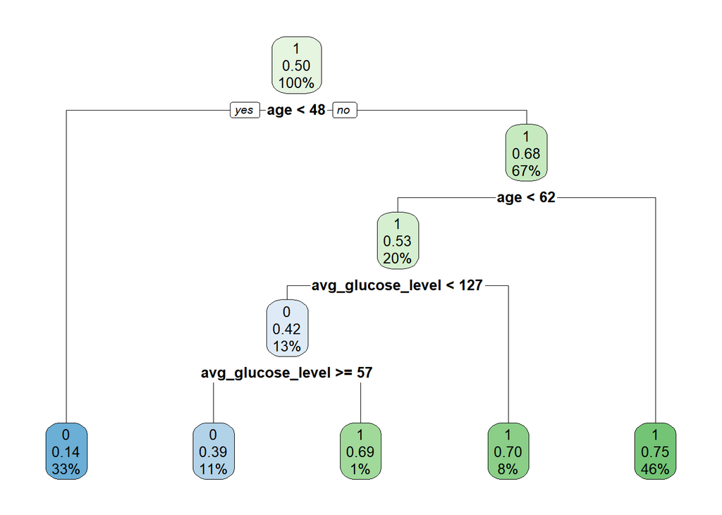

```r
fit <- rpart(stroke~ . , data = trainrose , method = 'class')
rpart.plot(fit, extra = 106)
```

```r
predict_unseen <-predict(fit, test1[-11], type = 'class')
confusion <- table(test1$stroke, predict_unseen)
confusion
```

```
##    predict_unseen
##       0   1
##   0 900 329
##   1  10  38
```

```r
confusion1= confusionMatrix(predict_unseen,test1$stroke,mode= "everything")
confusion1
```

```
## Confusion Matrix and Statistics
##
##           Reference
## Prediction   0   1
##          0 900  10
##          1 329  38
##
##                Accuracy : 0.7345
##                  95% CI : (0.7094, 0.7586)
##     No Information Rate : 0.9624
##     P-Value [Acc > NIR] : 1
##
##                   Kappa : 0.125
##
##  Mcnemar's Test P-Value : <2e-16
##
##             Sensitivity : 0.7323
##             Specificity : 0.7917
##          Pos Pred Value : 0.9890
##          Neg Pred Value : 0.1035
##               Precision : 0.9890
##                  Recall : 0.7323
##                      F1 : 0.8415
##              Prevalence : 0.9624
##          Detection Rate : 0.7048
##    Detection Prevalence : 0.7126
##       Balanced Accuracy : 0.7620
##
##        'Positive' Class : 0
##
```

```r
# Eval Metric
TN =confusion[1,1]
TP =confusion[2,2]
FP =confusion[1,2]
FN =confusion[2,1]
precision =(TP)/(TP+FP)
recall_score =(TP)/(TP+FN)
f1_score=2*((precision*recall_score)/(precision+recall_score))
accuracy_model  =(TP+TN)/(TP+TN+FP+FN)
FPR = FP/(FP+TN)
TPR = (TP)/(TP+FN)
print(paste('Accuracy for test', accuracy_model))
```

```
## [1] "Accuracy for test 0.734534064212999"
```

```r
print(paste('recall_score for test', recall_score))
```

```
## [1] "recall_score for test 0.791666666666667"
```

#### 5.1.2.1 DECISION TREE with feature selection

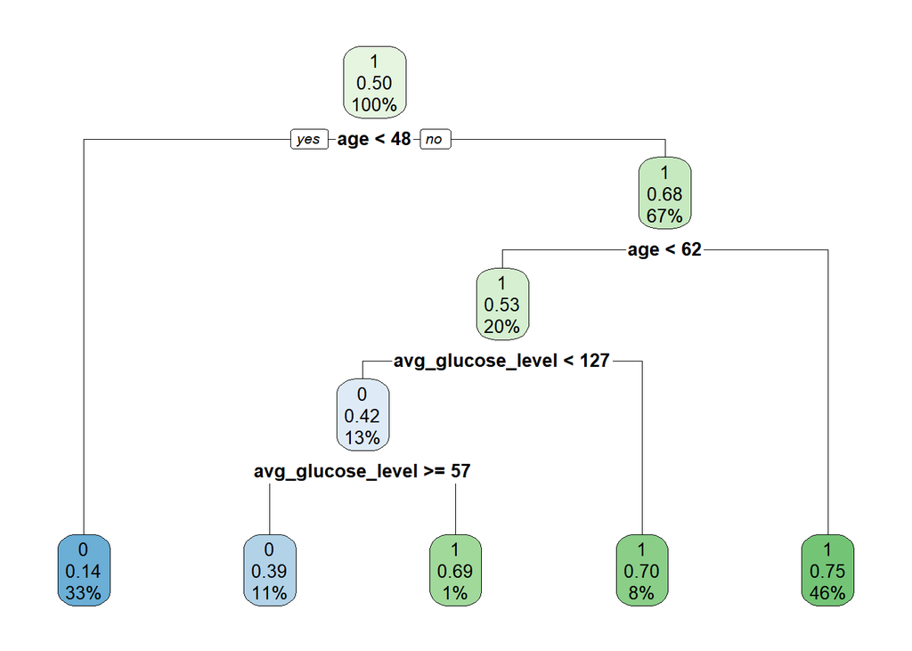

```r
fit <- rpart(stroke~ . , data = trainrose1 , method = 'class')
rpart.plot(fit, extra = 106)
```

```r
predict_unseen <-predict(fit, test1_fe[-7], type = 'class')
confusion <- table(test1_fe$stroke, predict_unseen)
confusion
```

```
##    predict_unseen
##       0   1
##   0 900 329
##   1  10  38
```

```r
confusion1= confusionMatrix(predict_unseen,test1_fe$stroke,mode= "everything")
confusion1
```

```
## Confusion Matrix and Statistics
##
##           Reference
## Prediction   0   1
##          0 900  10
##          1 329  38
##
##                Accuracy : 0.7345
##                  95% CI : (0.7094, 0.7586)
##     No Information Rate : 0.9624
##     P-Value [Acc > NIR] : 1
##
##                   Kappa : 0.125
##
##  Mcnemar's Test P-Value : <2e-16
##
##             Sensitivity : 0.7323
##             Specificity : 0.7917
##          Pos Pred Value : 0.9890
##          Neg Pred Value : 0.1035
##               Precision : 0.9890
##                  Recall : 0.7323
##                      F1 : 0.8415
##              Prevalence : 0.9624
##          Detection Rate : 0.7048
##    Detection Prevalence : 0.7126
##       Balanced Accuracy : 0.7620
##
##        'Positive' Class : 0
##
```

```r
# Eval Metric
TN =confusion[1,1]
TP =confusion[2,2]
FP =confusion[1,2]
FN =confusion[2,1]
precision =(TP)/(TP+FP)
recall_score =(TP)/(TP+FN)
f1_score=2*((precision*recall_score)/(precision+recall_score))
accuracy_model  =(TP+TN)/(TP+TN+FP+FN)
print(paste('Accuracy for test', accuracy_model))
```

```
## [1] "Accuracy for test 0.734534064212999"
```

```r
print(paste('recall_score for test', recall_score))
```

```
## [1] "recall_score for test 0.791666666666667"
```

### 5.1.3 Tuned decision tree

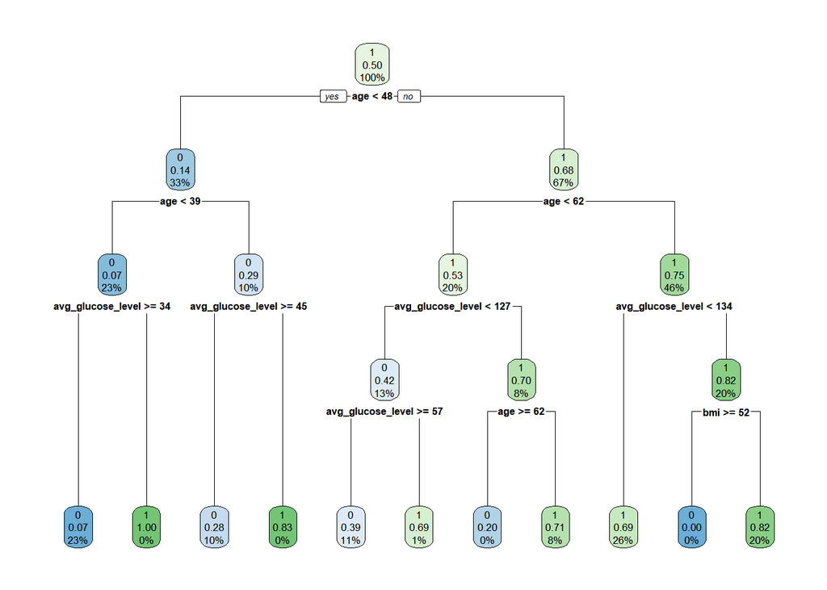

```r
control <- rpart.control(minsplit = 7,
    minbucket = round(5 / 3),
    maxdepth = 4,
    cp = 0)
tune_fit <- rpart(stroke~., data = trainrose , method = 'class', control = control)
rpart.plot(tune_fit, extra = 106)
```

```r
predict_unseen1 <-predict(tune_fit, test1, type = 'class')
confusion <- table(test1$stroke, predict_unseen1)
confusion
```

```
##    predict_unseen1
##       0   1
##   0 902 327
##   1  10  38
```

```r
confusion1= confusionMatrix(predict_unseen1,test1$stroke,mode= "everything")
confusion1
```

```
## Confusion Matrix and Statistics
##
##           Reference
## Prediction   0   1
##          0 902  10
##          1 327  38
##
##                Accuracy : 0.7361
##                  95% CI : (0.711, 0.7601)
##     No Information Rate : 0.9624
##     P-Value [Acc > NIR] : 1
##
##                   Kappa : 0.1259
##
##  Mcnemar's Test P-Value : <2e-16
##
##             Sensitivity : 0.7339
##             Specificity : 0.7917
##          Pos Pred Value : 0.9890
##          Neg Pred Value : 0.1041
##               Precision : 0.9890
##                  Recall : 0.7339
##                      F1 : 0.8426
##              Prevalence : 0.9624
##          Detection Rate : 0.7063
##    Detection Prevalence : 0.7142
##       Balanced Accuracy : 0.7628
##
##        'Positive' Class : 0
##
```

```r
# Eval Metric
TN =confusion[1,1]
TP =confusion[2,2]
FP =confusion[1,2]
FN =confusion[2,1]
precision =(TP)/(TP+FP)
recall_score =(TP)/(TP+FN)
f1_score=2*((precision*recall_score)/(precision+recall_score))
accuracy_model  =(TP+TN)/(TP+TN+FP+FN)
print(paste('Accuracy for test', accuracy_model))
```

```
## [1] "Accuracy for test 0.736100234925607"
```

```r
print(paste('recall_score for test', recall_score))
```

```
## [1] "recall_score for test 0.791666666666667"
```